# Introduction to Python Data Processing and Visualisation

### Adam Ruszkowski

29/09/2017

### Why Python

- Python allows us to quickly and reproducibly process data
- The syntax of the language is (relatively!!) easy to understand
- Numerous modules exist which take out some of the hard work

### Modules

- Python allows users to group together defined objects, variables and functions into a file so that tey can be used in other
- We will use several specialised modules which have to be installed separately by the user:
  - `numpy`
  - `matplotlib/seaborn`
  - `plotly`
- We have to `import` these into our program

```python
import matplotlib.pyplot as plt
%matplotlib inline
import seaborn as sns
sns.set_style('darkgrid')
sns.set_context('poster')
import pandas as pd
```

## Data Processing

### Pandas

- Pandas is a Python module which describes itself as:

  > an open source, BSD-licensed library providing high-performance, easy-to-use data structures and data analysis tools for the Python programming language.
- It processes data quickly, and has good interactions with Excel and CSV files
- Generally, data is imported into a `DataFrame`, which is a bit like an Excel worksheet

### Reading in Data

- Reading in data from a CSV file is very straightforward
- Multiple files can be read in, but for now we'll select one

```python
df = pd.read_csv('VBV_Data\VBV_20170131_JTC00567_shay_2940.csv', low_memory=False)
df.head(15)
```

|  | RecordedDataTime | SiteName | SpeedMPH | Class | Length(Metres) | Chasis Ht | Info | Gap | Lane | Direction |
| --- | --- | --- | --- | --- | --- | --- | --- | --- | --- | --- |
| 0 | 2016-06-01 00:01:04 | JTC00567 | 68 | 2 | 4 | NaN | Car / Small Van <5.2 metres | NaN | 1 | S |
| 1 | 2016-06-01 00:01:09 | JTC00567 | 64 | 2 | 4 | NaN | Car / Small Van <5.2 metres | 49.0 | 1 | S |
| 2 | 2016-06-01 00:01:12 | JTC00567 | 57 | 5 | 18 | NaN | Rigid HGV + Trailer / Standard Articulated (Ca... | NaN | 1 | N |
| 3 | 2016-06-01 00:01:25 | JTC00567 | 76 | 4 | 6 | NaN | Rigid HGV / Large Van | 158.0 | 1 | S |
| 4 | 2016-06-01 00:02:30 | JTC00567 | 58 | 4 | 8 | NaN | Rigid HGV / Large Van | NaN | 2 | N |
| 5 | 2016-06-01 00:02:30 | JTC00567 | 57 | 5 | 16 | NaN | Rigid HGV + Trailer / Standard Articulated (Ca... | 774.0 | 1 | N |
| 6 | 2016-06-01 00:03:05 | JTC00567 | 53 | 5 | 15 | NaN | Rigid HGV + Trailer / Standard Articulated (Ca... | 1002.0 | 1 | S |
| 7 | 2016-06-01 00:04:41 | JTC00567 | 58 | 5 | 18 | NaN | Rigid HGV + Trailer / Standard Articulated (Ca... | 950.0 | 1 | S |
| 8 | 2016-06-01 00:04:44 | JTC00567 | 77 | 2 | 4 | NaN | Car / Small Van <5.2 metres | 1335.0 | 1 | N |
| 9 | 2016-06-01 00:04:53 | JTC00567 | 66 | 2 | 3 | NaN | Car / Small Van <5.2 metres | 110.0 | 1 | S |
| 10 | 2016-06-01 00:04:58 | JTC00567 | 57 | 5 | 16 | NaN | Rigid HGV + Trailer / Standard Articulated (Ca... | 138.0 | 1 | N |
| 11 | 2016-06-01 00:05:08 | JTC00567 | 51 | 5 | 16 | NaN | Rigid HGV + Trailer / Standard Articulated (Ca... | 146.0 | 1 | S |
| 12 | 2016-06-01 00:05:10 | JTC00567 | 52 | 2 | 4 | NaN | Car / Small Van <5.2 metres | 21.0 | 1 | S |
| 13 | 2016-06-01 00:05:50 | JTC00567 | 61 | 2 | 4 | NaN | Car / Small Van <5.2 metres | 507.0 | 1 | N |
| 14 | 2016-06-01 00:06:04 | JTC00567 | 48 | 5 | 17 | NaN | Rigid HGV + Trailer / Standard Articulated (Ca... | 141.0 | 1 | N |

### Processing Data

- Once we have the data imported into `pandas`, we can start to manipulate it.
- Python (and `pandas`) can manipulate dates and times, if they're the correct kind of object.
- We can convert the strings, and calculate hourly counts in a few lines of code

```python
df['Count'] = 1
df['DateTime'] = pd.to_datetime(df['RecordedDataTime'])
df.set_index('DateTime', inplace=True)
hourly_counts = df.groupby([pd.TimeGrouper('1H'), 'Class'])['Count'].count().reset_index()
hourly_counts.head(15)
```

|  | DateTime | Class | Count |
| --- | --- | --- | --- |
| 0 | 2016-06-01 00:00:00 | 2 | 48 |
| 1 | 2016-06-01 00:00:00 | 3 | 2 |
| 2 | 2016-06-01 00:00:00 | 4 | 11 |
| 3 | 2016-06-01 00:00:00 | 5 | 27 |
| 4 | 2016-06-01 01:00:00 | 2 | 35 |
| 5 | 2016-06-01 01:00:00 | 3 | 3 |
| 6 | 2016-06-01 01:00:00 | 4 | 9 |
| 7 | 2016-06-01 01:00:00 | 5 | 31 |
| 8 | 2016-06-01 02:00:00 | 2 | 30 |
| 9 | 2016-06-01 02:00:00 | 3 | 2 |
| 10 | 2016-06-01 02:00:00 | 4 | 17 |
| 11 | 2016-06-01 02:00:00 | 5 | 39 |
| 12 | 2016-06-01 03:00:00 | 2 | 61 |
| 13 | 2016-06-01 03:00:00 | 3 | 1 |
| 14 | 2016-06-01 03:00:00 | 4 | 19 |

### Exporting Data

- Now that we have our data processed to provide the summaries we are interested in, we can export to a CSV as easily as we read the original data in

```python
hourly_counts.to_csv('JTC00567 Hourly Summaries.csv', index=False)
```

- We can also export more than one `DataFrame` to Excel

```python
excel_writer = pd.ExcelWriter('JTC00567.xlsx')
df.to_excel(excel_writer, 'Raw Counts', index=False)
hourly_counts.to_excel(excel_writer, 'Hourly Counts', index=False)
excel_writer.save()
```

## Data Visualisation

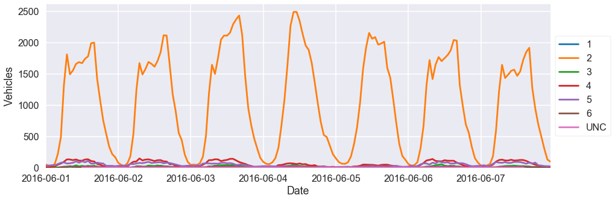

```python
fig, ax = plt.subplots(figsize=(15, 5))
#sns.pointplot(data=hourly_counts, x='DateTime', y='Count', hue='Class', markers='')
for cls, data in hourly_counts.groupby('Class'):
    ax.plot_date(data['DateTime'], data['Count'], label=cls, linestyle='-', marker='')

plt.legend(frameon=True, facecolor='white', loc='center left', bbox_to_anchor=(1, 0.5))
plt.ylim(bottom=0)
plt.xlabel('Date')
plt.ylabel('Vehicles')
ax.margins(x=0)
```

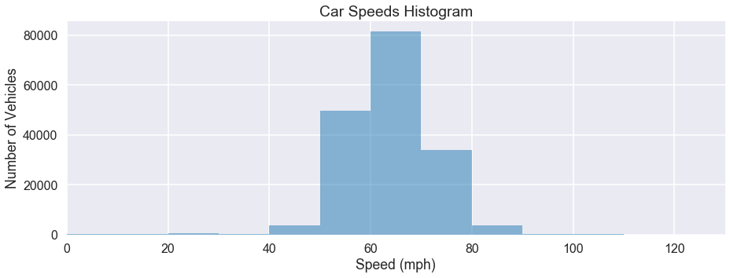

```python
fig, ax = plt.subplots(figsize=(15, 5))

cars = df[df['Class'] == '2']
bin_size = 10
bins = range(0,max(cars['SpeedMPH']) + bin_size, bin_size)

cars.hist(column='SpeedMPH', bins=bins, ax=ax, alpha=0.5)
plt.xlabel('Speed (mph)')
plt.ylabel('Number of Vehicles')
plt.title('Car Speeds Histogram')
ax.margins(x=0)
```